# Coursework Report

*N* removed NAs: 3

*N* removed typo: 1

*N* removed <18: 30

*N* total clean: 116

| Group | *N* | *M*<sub>age</sub> | *M*<sub>rating</sub> |
| --- | --- | --- | --- |
| Control | 60 | 20.9 | 6.29 |
| Experim | 56 | 21.0 | 5.52 |

**Main analysis results**

*t*(114) = 5.05, *p* < .001

[interactive chart not shown]

[figure not shown]

[interactive chart not shown]

# Coursework Report

Analysing Data, Spring 2020

# Methods

## Participants

This experiment initially included 150 participants. Participants removed included those who gave incorrect submissions of their age or who were too young to be ethically included in this study – this included any participant who submitted an age below 18 years old. The analysis of data therefore included 116 participants.

Summary of Participant Demographics by Experimental Condition

| Conditon | Number of Participants | *M*<sub>Age</sub> | *SD*<sub>Age</sub> | *MIN*<sub>Age</sub> | *MAX*<sub>Age</sub> |
| --- | --- | --- | --- | --- | --- |
| Control | 60 | 20.9 | 2.14 | 18 | 28 |
| Experimental | 56 | 21.0 | 2.03 | 18 | 26 |

All participants involved were female and of normal colour vision that would not interfere with the experiment, e.g. red/green colour deficiency.

## Design

The experiment investigated whether women viewing men in conjunction with the colour red would produce higher levels of attraction than white, a so-called neutral ‘*unobtrusive*’ colour (Elliot et al., 2010, pg. 403). This independent-measures design study investigated this by presenting either a red-framed or white-framed 4-inch x 6-inch image of the same ‘*moderately attractive, young Caucasian man*’ (Elliot et al., 2010, pg. 403) to individual participants for a duration of five seconds. The independent variable was whether participants viewed the picture of the man with a red frame or white frame around him.

Participants then completed a questionnaire comprised of three questions related to perceived attractiveness – the study’s dependent variable. The questions were as follows: ‘*How attractive do you think this person is?*’, ‘*How pleasant is this person to look at?*’, and ‘*If I were to meet the person in this picture face to face, I would think he’s attractive.*’. These were answered on a 9-point Likert scale, from 1 - ‘*Not at all attractive*’ to 9 - ‘*Extremely attractive*’. Results were then composited, grouped by condition, and an independent-measures *t*-test analysis was used to determine statistical significance.

# Results

Over all three questions, the control group scored the image as more attractive than in the red experimental group. Questions one and two were scored significantly higher when using an independent-measures *t*-test with a significance score of *p* < 0.001 and *p* = 0.001 respectively. The final question was not statistically different across participants mean score, *p* = 0.076. However, when creating a composite score by condition, it was found using the *t*-test analysis that there was a significant difference in the means of the two groups, showing the control group as having a higher attraction to the pictured man, with a mean score of *M* = 6.29 and the experimental group with a mean of *M* = 5.52. The significance measured as (*M*<sub>diff</sub> = 0.78, 95% CI [0.47, 1.08], *t* (114) = 5.05, *p* < 0.001).

Mean Attraction Rating by Conditon

| Colour Conditon | *M*<sub>Attraction</sub> | *SD*<sub>Attraction</sub> |
| --- | --- | --- |
| Control | 6.29 | 1.41 |
| Experimental | 5.52 | 1.35 |

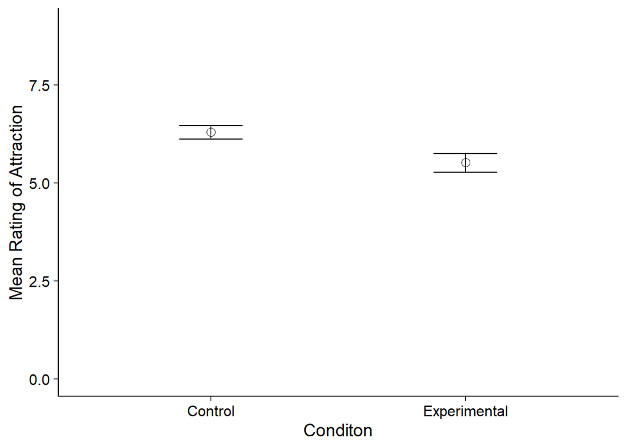

# Discussion

In summary, white acts as a better attraction colour than red when women view men in conjuction with those two colours. The composite score of the three initial questions showed that the control white group had a statistcally greater mean that the red group, determined by an independent *t*-test. This contradicts the initial study conducted by Elliot et al. (2010) whereby red was found to statistaically encourage attraction over white, and perhaps undermines the conclusions drawn as a result.

This might indicate that while colour has an effect on attraction levels, the reasoning behind different colours’ effects is unknown. For instance, while this study found white to be significantly greater than red in encouraging attraction, Elliot et al. (2010) found that red was statisically rated higher in attraction ratings, and was even linked to status in a range of other experiments.

Plenty of studies also support Elliot et al.’s claims that red is linked with attraction, with cross cultural studies linking red to love and passion (Aslam, 2006; Jacobs, Keown, Worthley & Gyhmn, 1991; Neto, 2002). Multiple studies indicating red as a endearing colour may cause doubt to this study’s result, however the study did attempt to replicate the initial study to the best of its abilities.

One of the key difference was the sample group, however if this effect is universal, indicated by cross cultural studies (Aslam, 2006; Jacobs et al., 1991; Neto, 2002) then this should not make a significant difference. Perhaps one cause for these differences is that the effect of colour is largely mediated by cultural factors, as Peperkoorn, Roberts and Pollet (2016) investigated. Perhaps the sample group selected was similar in the sense that they were not socialised to associate red with status and therefore link it to attracation ratings, like Elliot et al. (2010) finds. In Pazda, Elliot and Greitemeyer’s (2012) study they found no signifiacant differences between the colour red and black, but that white was found to be less attractive. Alternatively, a similar study found no significant differnences between red, white or black apparel (Lynn, Giebelhausen, Garcia and Patumanon, 2016).

These studies however all looked at the effect of mens’ ratings of attraction of women associated with various colours, and so it is difficult to compare to a woman viewing a man in various colours. If there are links to status and colour, then there might be differences in sex’s ratings as there may be different priorites when finding someone attractive. The only study that thoroughly looked at women’s rating was Elliot et al. (2010), which our study contradicts. This is evidence however that more reseach needs to investiagte colour-effects in attraction for women – rather than the androcentric approch curerently taken.

The initial claim by Elliot et al. (2010) that white is an ‘*unobtrusive*’ colour could also be debated. All colours are associated with certain emotions, symbols and biases. Perhaps red being linked to love and passion (Aslam, 2006; Jacobs et al., 1991; Neto, 2002) is less important to women that might prefer white, linked peace and purity. Yela (2004) looked at the halo effect in conjuction to interpersonal attraction. If white is seen moreso as beautiful and good than red it could explain the results found in this study. Perhaps if the study looked more thoroughly about individual’s beliefs about different colours then it would give us a more comprehensive idea as to why white scored significantly higher on an attraction rating than red, contrary to previous studies.

The findings may be a result of this study being more contemporary than Elliot et al.’s (2010). As society’s evaluation of symbols changes rapidly, red may have once been a positive attractor, but now is outdated and white is viewed more positively.

Overall, the reason as to why the study found the effect is unknown, however as the sample size was larger than Elliot et al.’s (2010) study and is more recent. This might indicate that white is now seen as a greater colour for attraction ratings than red. It does need to be taken into consideration however that Elliot et al. (2010) completed seven separate experiments focusing on different aspects of various colours and their links to attraction. This comprehensive insight into various factors, like whether the image viewed was framed a certain colour or the model wore the colour, the differences between male and female viewers, and the link between red and status, all provide a really strong argument towards red as a positive encourager of perceived attraction.

This study however did not find that, and while more could have been done – like investigating the associations between colour and its percieved meaning, we still cannot accept the hypothesis that women viewing men in conjunction with the colour red will produce higher levels of attraction than white. Perhaps different results would have been found in a forced-choice task between a white and red framed model, or in a repeated-measures study, but this study cannot comment on those possibilities.

The question of whether colour can influence attraction ratings needs to be researched further. This study questions some of the key work done by Elliot et al. (2010) as well as other publishers and so further insight as to why that might have been is essential. Perhaps mood can effect perception. Perhaps it could be that some social groups have more positive connotations with white over red, for example. Women as the raters of attraction is also severly underreaseached as the literature tends to have taken a mostly androcentric approach. This allows little insight into sex-differences and also means results from male-studies are potentially wrongly generalised to women.

Most importantly, a better understanding of why colour can infuence attraction is vital. Whether this be via biological roots or through socialisation, colour can connote a variety of meanings and those meanings need to be unpicked to determine what causes them to portray a more attractive image. Thourough content-analysis from a questioinnaire focusing on beliefs and colour association may help seperate the positive and negative links to colours. Studies then looking at a variety of colours and their subsequent attraction ratings may further help understanding of what encourages attraction.

This experiment found that maniplating the colour that a female-rater saw in conjuntion to a male model signifucantly changed the attraction score they gave. White, *M* = = 6.29, was significantly rated higher than red, *M* = 5.52, determined by an independent-measures *t*-test, *p* < 0.001. This meant that viewing a white-framed male model meant a higher scoring of attraction than the same red-framed model.

The associations made with white must have been important enough to the participants that it increased their rating by a significant amount, perhaps indicating that white positively influences the way women score attraction – at least more so than red. The main limitation is that the qualitative understanding of why women found white to increase their attraction was not investigated. This makes it difficult to conclude why the results were found without speculation. As a result, more research needs to develop a comprehensive evaluation of different colour and their associated meaning – for both male and female participants.

This study challenges the initial study by Elliot et al. (2010) and perhaps calls for a full repliaction of all seven experiments to see whether the results remain the same. The results contradicting the replicated study also highlights the importance of peer-review and repeated experiments in order to prevent misinformation spreading within the psychology community. More experiments focusing on certain aspects of the experiment would help piece together the larger picture and would allow fewer sweeping conclusions to be made without the proper scientific method supporting it. It would be wrong for the study to conclude that white causes a higher attraction rating than red, given the multitude of research suggesting otherwise, however this study also did not get these results by chance, determined by the statistical analysis *t*-test and so further exploration is needed.

# References

Aslam, M. M. (2006). Are You Selling the Right Colour? A Cross‐cultural Review of Colour as a Marketing Cue. Journal of Marketing Communications, 12(1), 15–30. https://doi.org/10.1080/13527260500247827

Elliot, A. J., Kayser, D. N., Greitemeyer, T., Lichtenfeld, S., Gramzow, R. H., Maier, M. A., & Liu, H. (2010). Red, rank, and romance in women viewing men. Journal of Experimental Psychology. General, 139(3), 399–417. https://doi.org/10.1037/a0019689

Jacobs, L., Keown, C., Worthley, R., & Ghymn, K. (1991). Cross‐cultural Colour Comparisons: Global Marketers Beware! International Marketing Review, 8(3). https://doi.org/10.1108/02651339110137279

Lynn, M., Giebelhausen, M., Garcia, S., Li, Y., & Patumanon, I. (2016). Clothing color and tipping: An attempted replication and extension. Journal of Hospitality & Tourism Research, 40(4), 516–524. https://doi.org/10.1177/1096348013504001

Neto, F. (2016). Colors Associated with Styles of Love: Perceptual and Motor Skills. https://doi.org/10.2466/pms.2002.94.3c.1303

Pazda, A. D., Elliot, A. J., & Greitemeyer, T. (2014). Perceived sexual receptivity and fashionableness: Separate paths linking red and black to perceived attractiveness. Color Research & Application, 39(2), 208–212. https://doi.org/10.1002/col.21804

on attractiveness and sexual receptivity: No effect of the color red on human mate preferences. Evolutionary Psychology, 14(4). https://doi.org/10.1177/1474704916673841

Yela, C. (2004). Interpersonal Attraction. In C. D. Spielberger (Ed.), Encyclopedia of Applied Psychology (pp. 379–385). Elsevier. https://doi.org/10.1016/B0-12-657410-3/00057-X